# practice_data

Yochai Shavit

October 29, 2017

# set wd

```r
getwd()
```

```
## [1] "C:/Users/Yochai Shavit/Documents/Stanford Ph.D/3rd year/Psych 251/Replication project/gong2017/practice_analysis"
```

# load packages

```r
library(knitr)
library(tidyverse)
library(lavaan)
library(car)
library(broom)
library(ez)
library(lme4)
library(lmerTest)
library(pander)
```

# create data

First, create dataset as it will be downloaded from Qualtrix (wide form with raw values of time and money in each of the conditions), including demographic data. This is to test if I can fit the hyperbolic discount function in R

This dataset is obviously full of impossible values (negative number of friends or value of donations). Would it make sense to set all negative values to zero? In the paper they mention fitting the curve to the group median data because it is typically not normally distributed, so using a normal distribution here probabky wouldn’t be different because the mean would be the same as the median.

# create second dataset, with random sampling from a certain range of values

# Descriptive demographics and statistics

Measure of central tendency and age group differences as reported in the original paper

```r
#table of descpritive statistics
dscrpt=df_og%>%group_by(age_grp)%>%summarise(male_female_ratio=paste(sum(gender=="male"), "/", sum(gender=="female")),
Age_av=mean(age),Age_sd=sd(age),
Education_av=mean(edu_lv),Education_sd=sd(edu_lv), Household_income_av=mean(incm_lv),Household_income_sd=sd(incm_lv), sig_relatives_av=mean(num_relatives),sig_relatives_sd=sd(num_relatives),
sig_friends_av=mean(num_friends), sig_friends_sd=sd(num_friends))

kable(dscrpt, digits = 2, align='c', caption = "decsriptive statistics by age group")
```

decsriptive statistics by age group

| age_grp | male_female_ratio | Age_av | Age_sd | Education_av | Education_sd | Household_income_av | Household_income_sd | sig_relatives_av | sig_relatives_sd | sig_friends_av | sig_friends_sd |
| --- | --- | --- | --- | --- | --- | --- | --- | --- | --- | --- | --- |
| old | 27 / 27 | 75.33 | 8.75 | 2.48 | 1.19 | 0.95 | 0.59 | 11.71 | 11.62 | 12.17 | 9.27 |
| young | 27 / 27 | 26.81 | 5.44 | 4.09 | 0.83 | 0.89 | 0.51 | 8.31 | 6.21 | 8.11 | 7.64 |

```r
#Gender (chi-square)
with(df_og,
print(chisq.test(gender, age_grp, rescale.p = T, correct = F)))
```

```
##
##  Pearson's Chi-squared test
##
## data:  gender and age_grp
## X-squared = 0, df = 1, p-value = 1
```

```r
#Age
with(df_og,
print(t.test(age~age_grp)))
```

```
##
##  Welch Two Sample t-test
##
## data:  age by age_grp
## t = 34.605, df = 88.593, p-value < 2.2e-16
## alternative hypothesis: true difference in means is not equal to 0
## 95 percent confidence interval:
##  45.73245 51.30458
## sample estimates:
##   mean in group old mean in group young
##            75.33333            26.81481
```

```r
#education level
with(df_og,
print(t.test(edu_lv~age_grp)))
```

```
##
##  Welch Two Sample t-test
##
## data:  edu_lv by age_grp
## t = -8.1436, df = 94.57, p-value = 1.539e-12
## alternative hypothesis: true difference in means is not equal to 0
## 95 percent confidence interval:
##  -2.003893 -1.218330
## sample estimates:
##   mean in group old mean in group young
##            2.481481            4.092593
```

```r
#income level
with(df_og,
print(t.test(incm_lv~age_grp)))
```

```
##
##  Welch Two Sample t-test
##
## data:  incm_lv by age_grp
## t = 0.63886, df = 103.84, p-value = 0.5243
## alternative hypothesis: true difference in means is not equal to 0
## 95 percent confidence interval:
##  -0.1428311  0.2785959
## sample estimates:
##   mean in group old mean in group young
##           0.9534817           0.8855993
```

```r
#number of close relatives
with(df_og,
print(t.test(num_relatives~age_grp)))
```

```
##
##  Welch Two Sample t-test
##
## data:  num_relatives by age_grp
## t = 1.8987, df = 80.996, p-value = 0.06116
## alternative hypothesis: true difference in means is not equal to 0
## 95 percent confidence interval:
##  -0.1630448  6.9713377
## sample estimates:
##   mean in group old mean in group young
##           11.712892            8.308746
```

```r
#number of close friends
with(df_og,
print(t.test(num_friends~age_grp)))
```

```
##
##  Welch Two Sample t-test
##
## data:  num_friends by age_grp
## t = 2.4866, df = 102.28, p-value = 0.01452
## alternative hypothesis: true difference in means is not equal to 0
## 95 percent confidence interval:
##  0.8227149 7.3092638
## sample estimates:
##   mean in group old mean in group young
##           12.172020            8.106031
```

**Note-** These data serve, to some extent, as a simulation of the dempgraphic effects in the original paper. The fact that the simulated values for number of close friends and relatives is sometime significant and sometimes not (for both) suggests that the finding that age groups differed in number of relatives but not in number of friends is at the very least fragile.

# Tidy data

data needs to be long-form for the first step, whereby each row is one trail for one subject (each subject has 14 rows (donation form * social distance), for each of the 2 kinship conditions (relative/nonrelative), resulting in 28 rows in total for 108 participants, meaning 3024 observations. In addition, add age_group variable.

```r
#long-form dataset
og_lng=df_og%>%
  gather(condition, amount,
         rel_1_mon,rel_2_mon,rel_5_mon,rel_10_mon,rel_20_mon, rel_50_mon, rel_100_mon,
         rel_1_time,rel_2_time,rel_5_time,rel_10_time,rel_20_time, rel_50_time, rel_100_time,
         nonrel_1_mon,nonrel_2_mon,nonrel_5_mon,nonrel_10_mon,nonrel_20_mon, nonrel_50_mon, nonrel_100_mon,
         nonrel_1_time,nonrel_2_time,nonrel_5_time,nonrel_10_time,nonrel_20_time, nonrel_50_time, nonrel_100_time
         )%>%
  separate(condition, c("kin", "soc_dist", "donation"), "_")%>%
  spread(kin, amount)%>%
  gather(kinship, amount,
         rel,nonrel) #-> That works!
```

# Curve fitting

Now that the dataset is tidy, proceed to attemp and fit the hyperbolic discount curve to the median value in each group (age_group-kinship-donation form)

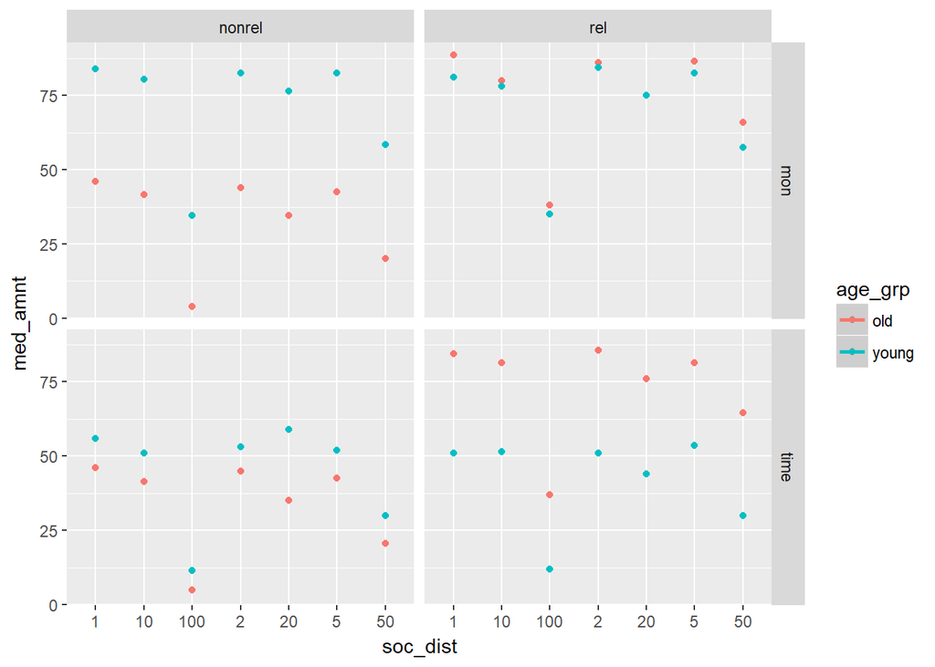

```r
med_table=og_lng%>%group_by(age_grp,kinship,donation,soc_dist)%>%summarise(med_amnt=median(amount))
#write_csv(med_table,"med_table_shavit.csv")

ggplot(data=med_table, aes(x=soc_dist, y=med_amnt, color=age_grp))+
  geom_point()+
  geom_smooth(method = "lm", formula = y~poly(x,2))+
  facet_grid(donation~kinship)
```

```r
#for each age_grp*kinship*donation condition
old_rel_mon=med_table%>%filter(age_grp=="old" & kinship=="rel" & donation=="mon")
kable(old_rel_mon, digits = 2, align = 'c', caption = "Older,relative,money: median amount given")
```

Older,relative,money: median amount given

| age_grp | kinship | donation | soc_dist | med_amnt |
| --- | --- | --- | --- | --- |
| old | rel | mon | 1 | 88.5 |
| old | rel | mon | 10 | 80.0 |
| old | rel | mon | 100 | 38.0 |
| old | rel | mon | 2 | 86.0 |
| old | rel | mon | 20 | 75.0 |
| old | rel | mon | 5 | 86.5 |
| old | rel | mon | 50 | 66.0 |

```r
old_rel_time=med_table%>%filter(age_grp=="old" & kinship=="rel" & donation=="time")
kable(old_rel_time, digits = 2, align = 'c', caption = "Older,relative,time: median amount given")
```

Older,relative,time: median amount given

| age_grp | kinship | donation | soc_dist | med_amnt |
| --- | --- | --- | --- | --- |
| old | rel | time | 1 | 84.5 |
| old | rel | time | 10 | 81.5 |
| old | rel | time | 100 | 37.0 |
| old | rel | time | 2 | 85.5 |
| old | rel | time | 20 | 76.0 |
| old | rel | time | 5 | 81.5 |
| old | rel | time | 50 | 64.5 |

```r
yng_rel_mon=med_table%>%filter(age_grp=="young" & kinship=="rel" & donation=="mon")
kable(yng_rel_mon, digits = 2, align = 'c', caption = "Younger,relative,money: median amount given")
```

Younger,relative,money: median amount given

| age_grp | kinship | donation | soc_dist | med_amnt |
| --- | --- | --- | --- | --- |
| young | rel | mon | 1 | 81.0 |
| young | rel | mon | 10 | 78.0 |
| young | rel | mon | 100 | 35.0 |
| young | rel | mon | 2 | 84.5 |
| young | rel | mon | 20 | 75.0 |
| young | rel | mon | 5 | 82.5 |
| young | rel | mon | 50 | 57.5 |

```r
yng_rel_time=med_table%>%filter(age_grp=="young" & kinship=="rel" & donation=="time")
kable(yng_rel_time, digits = 2, align = 'c', caption = "Younger,relative,time: median amount given")
```

Younger,relative,time: median amount given

| age_grp | kinship | donation | soc_dist | med_amnt |
| --- | --- | --- | --- | --- |
| young | rel | time | 1 | 51.0 |
| young | rel | time | 10 | 51.5 |
| young | rel | time | 100 | 12.0 |
| young | rel | time | 2 | 51.0 |
| young | rel | time | 20 | 44.0 |
| young | rel | time | 5 | 53.5 |
| young | rel | time | 50 | 30.0 |

```r
old_nonrel_mon=med_table%>%filter(age_grp=="old" & kinship=="nonrel" & donation=="mon")
kable(old_nonrel_mon, digits = 2, align = 'c', caption = "Older,non-relative,money: median amount given")
```

Older,non-relative,money: median amount given

| age_grp | kinship | donation | soc_dist | med_amnt |
| --- | --- | --- | --- | --- |
| old | nonrel | mon | 1 | 46.0 |
| old | nonrel | mon | 10 | 41.5 |
| old | nonrel | mon | 100 | 4.0 |
| old | nonrel | mon | 2 | 44.0 |
| old | nonrel | mon | 20 | 34.5 |
| old | nonrel | mon | 5 | 42.5 |
| old | nonrel | mon | 50 | 20.0 |

```r
old_nonrel_time=med_table%>%filter(age_grp=="old" & kinship=="nonrel" & donation=="time")
kable(old_nonrel_time, digits = 2, align = 'c', caption = "Older,non-relative,time: median amount given")
```

Older,non-relative,time: median amount given

| age_grp | kinship | donation | soc_dist | med_amnt |
| --- | --- | --- | --- | --- |
| old | nonrel | time | 1 | 46.0 |
| old | nonrel | time | 10 | 41.5 |
| old | nonrel | time | 100 | 5.0 |
| old | nonrel | time | 2 | 45.0 |
| old | nonrel | time | 20 | 35.0 |
| old | nonrel | time | 5 | 42.5 |
| old | nonrel | time | 50 | 20.5 |

```r
yng_nonrel_mon=med_table%>%filter(age_grp=="young" & kinship=="nonrel" & donation=="mon")
kable(yng_nonrel_mon, digits = 2, align = 'c', caption = "Younger,non-relative,money: median amount given")
```

Younger,non-relative,money: median amount given

| age_grp | kinship | donation | soc_dist | med_amnt |
| --- | --- | --- | --- | --- |
| young | nonrel | mon | 1 | 84.0 |
| young | nonrel | mon | 10 | 80.5 |
| young | nonrel | mon | 100 | 34.5 |
| young | nonrel | mon | 2 | 82.5 |
| young | nonrel | mon | 20 | 76.5 |
| young | nonrel | mon | 5 | 82.5 |
| young | nonrel | mon | 50 | 58.5 |

```r
yng_nonrel_time=med_table%>%filter(age_grp=="young" & kinship=="nonrel" & donation=="time")
kable(yng_nonrel_time, digits = 2, align = 'c', caption = "Younger,non-relative,time: median amount given")
```

Younger,non-relative,time: median amount given

| age_grp | kinship | donation | soc_dist | med_amnt |
| --- | --- | --- | --- | --- |
| young | nonrel | time | 1 | 56.0 |
| young | nonrel | time | 10 | 51.0 |
| young | nonrel | time | 100 | 11.5 |
| young | nonrel | time | 2 | 53.0 |
| young | nonrel | time | 20 | 59.0 |
| young | nonrel | time | 5 | 52.0 |
| young | nonrel | time | 50 | 30.0 |

# Code from Mike

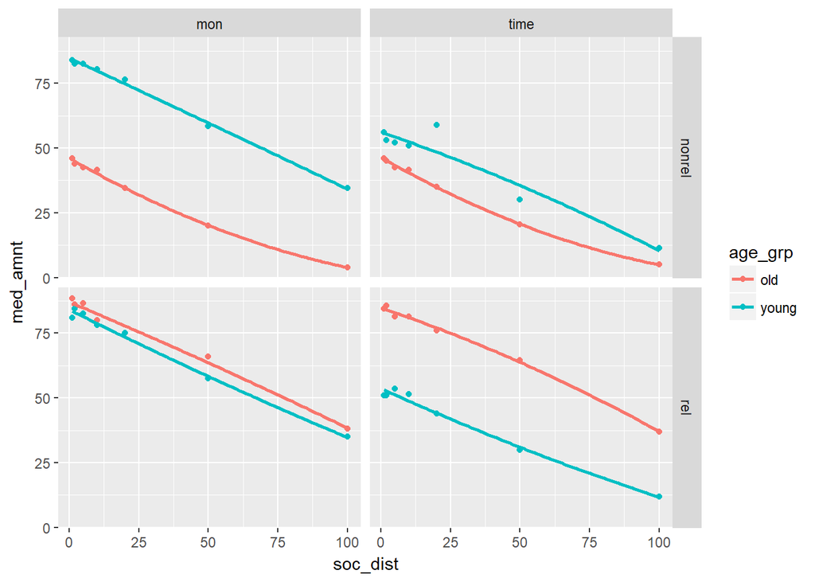

```r
#define dataset
d=med_table
d$soc_dist=as.numeric(d$soc_dist)

# first plot
ggplot(d,
       aes(x = soc_dist, y = med_amnt, col = age_grp)) +
  geom_point() +
  facet_grid(kinship ~ donation) +
  geom_smooth(method="lm", formula = y ~ poly(x, 2),
              se = FALSE)
```

```r
# for testing
data_subset <- filter(d, age_grp == "old",
                      kinship == "nonrel",
                      donation == "mon")

# v=V/(1 +kN)
# where V is the undiscounted reward value,
# v is the reward value that a person would like to forgo for the benefit for someone at a social distance N, and k is a constant indexing degree of social discounting (i.e., discount rate) across social distances.

# where R-square and root-mean-square error (RMSE) were used to assess the goodness of  fit.

# compute the hyperbolic function
discount <- function (V, k, N) {
  nu <- V / (1 + k * N)

  return(nu)
}

# compute RMSE for a given parameter set and data
data_vs_discount <- function(V, k, N, amount) {
  nu <- discount(V, k, N)

  RMSE <- sqrt(mean((amount - nu)^2))

  return(RMSE)
}

# wrapper to feed to optim
optim_discount_wrapper <- function(x) {
  return(data_vs_discount(V = x[1], k = x[2],
                          N = data_subset$soc_dist,
                          amount = data_subset$med_amnt))
}

# try fitting optimizer
opt1=optim(c(100, .2), optim_discount_wrapper)
opt1 #-> first par= V, second par=k
```

```
## $par
## [1] 48.92635298  0.02999764
##
## $value
## [1] 3.875922
##
## $counts
## function gradient
##      103       NA
##
## $convergence
## [1] 0
##
## $message
## NULL
```

```r
# get predictions on test case
data_subset$pred <- discount(V = 48, k = .02,
                             N = data_subset$soc_dist)

#Get R^2 for predictions and data
cor1=cor.test(data_subset$med_amnt, data_subset$pred)
(cor1$estimate)^2 #-> R^2 value
```

```
##       cor
## 0.9682764
```

# Run for each age group, donation and kinship combination

```r
#create empty vectors to store values
age_grp=vector(mode="character",length=0); donation=vector(mode="character",length=0); kinship=vector(mode="character",length=0); V_values=vector(mode="numeric",length=0); k_values=vector(mode="numeric",length=0); RMSE=vector(mode="numeric",length=0); R_sq=vector(mode="numeric",length=0)

#run for each age group, exctract values for donation * kinship conditions

for(i in unique(d$age_grp)){

  d_mon_rel=d%>%filter(age_grp==i, donation=="mon", kinship=="rel") #-> create temp df to get values from
  age_grp=c(age_grp,i) #-> store the appropriate age group
  donation=c(donation, "mon") #-> store the appropriate donation
  kinship=c(kinship, "rel") #-> store the appropriate kinship
  optim_discount_wrapper <- function(x) { #-> define discount wrapper to get V, k, and RMSE values for this                                                      condition
  return(data_vs_discount(V = x[1], k = x[2],
                          N = d_mon_rel$soc_dist,
                          amount = d_mon_rel$med_amnt))
}

  opt1=optim(c(100, .2), optim_discount_wrapper) #-> run discount_wrapper
  V_values=c(V_values,opt1$par[1]) #-> store resulting V_value
  k_values=c(k_values, opt1$par[2]) #-> store resulting k_value
  RMSE=c(RMSE, opt1$value) #-> store resulting RMSE value
  d_mon_rel$pred=discount(V = opt1$par[1], k = opt1$par[2],N = d_mon_rel$soc_dist) #-> store predictions in temp                                                                                          dataset
  cor1=cor.test(d_mon_rel$med_amnt, d_mon_rel$pred) #-> run cor.test to get correlation of predictions and data
  R_sq=c(R_sq, (cor1$estimate)^2) #-> square the estimate (pearson's R) to get R^2.


  d_mon_nonrel=d%>%filter(age_grp==i, donation=="mon", kinship=="nonrel") #-> do all of this for the next donation                                                                               * Kinship condition
  age_grp=c(age_grp,i)
  donation=c(donation, "mon")
  kinship=c(kinship, "nonrel")
  optim_discount_wrapper <- function(x) {
  return(data_vs_discount(V = x[1], k = x[2],
                          N = d_mon_nonrel$soc_dist,
                          amount = d_mon_nonrel$med_amnt))
}

  opt2=optim(c(100, .2), optim_discount_wrapper)
  V_values=c(V_values,opt2$par[1])
  k_values=c(k_values, opt2$par[2])
  RMSE=c(RMSE, opt2$value)
  d_mon_nonrel$pred=discount(V = opt2$par[1], k = opt2$par[2],N = d_mon_nonrel$soc_dist)
  cor2=cor.test(d_mon_nonrel$med_amnt, d_mon_nonrel$pred)
  R_sq=c(R_sq, (cor2$estimate)^2)


  d_time_rel=d%>%filter(age_grp==i, donation=="time", kinship=="rel")
  age_grp=c(age_grp,i)
  donation=c(donation, "time")
  kinship=c(kinship, "rel")
  optim_discount_wrapper <- function(x) {
  return(data_vs_discount(V = x[1], k = x[2],
                          N = d_time_rel$soc_dist,
                          amount = d_time_rel$med_amnt))
}

  opt3=optim(c(100, .2), optim_discount_wrapper)
  V_values=c(V_values,opt3$par[1])
  k_values=c(k_values, opt3$par[2])
  RMSE=c(RMSE, opt3$value)
  d_time_rel$pred=discount(V = opt3$par[1], k = opt3$par[2],N = d_time_rel$soc_dist)
  cor3=cor.test(d_time_rel$med_amnt, d_time_rel$pred)
  R_sq=c(R_sq, (cor3$estimate)^2)


  d_time_nonrel=d%>%filter(age_grp==i, donation=="time", kinship=="nonrel")
  age_grp=c(age_grp,i)
  donation=c(donation, "time")
  kinship=c(kinship, "nonrel")
  optim_discount_wrapper <- function(x) {
  return(data_vs_discount(V = x[1], k = x[2],
                          N = d_time_nonrel$soc_dist,
                          amount = d_time_nonrel$med_amnt))
}

  opt4=optim(c(100, .2), optim_discount_wrapper)
  V_values=c(V_values,opt4$par[1])
  k_values=c(k_values, opt4$par[2])
  RMSE=c(RMSE, opt4$value)
  d_time_nonrel$pred=discount(V = opt4$par[1], k = opt4$par[2],N = d_time_nonrel$soc_dist)
  cor4=cor.test(d_time_nonrel$med_amnt, d_time_nonrel$pred)
  R_sq=c(R_sq, (cor4$estimate)^2)

}

#Add all vectors to one dataset
med_smry=as.data.frame(cbind(age_grp, donation, kinship, V_values, k_values, R_sq, RMSE), row.names = F)%>%mutate(V_values=as.character(V_values), k_values=as.character(k_values), R_sq=as.character(R_sq), RMSE=as.character(RMSE))%>%mutate(V_values=as.numeric(V_values), k_values=as.numeric(k_values), R_sq=as.numeric(R_sq), RMSE=as.numeric(RMSE))

kable(med_smry, digits = 2, align = "c", caption = "Estimated Parameters and Goodness-of-fit Indices of the Hyperbolic Functions, group median values")
```

Estimated Parameters and Goodness-of-fit Indices of the Hyperbolic Functions, group median values

| age_grp | donation | kinship | V_values | k_values | R_sq | RMSE |
| --- | --- | --- | --- | --- | --- | --- |
| old | mon | rel | 89.65 | 0.01 | 0.95 | 3.62 |
| old | mon | nonrel | 48.93 | 0.03 | 0.94 | 3.88 |
| old | time | rel | 87.61 | 0.01 | 0.94 | 3.87 |
| old | time | nonrel | 49.11 | 0.03 | 0.95 | 3.59 |
| young | mon | rel | 86.31 | 0.01 | 0.96 | 3.31 |
| young | mon | nonrel | 87.29 | 0.01 | 0.96 | 3.69 |
| young | time | rel | 55.96 | 0.02 | 0.93 | 4.08 |
| young | time | nonrel | 58.86 | 0.02 | 0.81 | 7.18 |

# finding AUC

```r
# first step - using Erin calculous calculator (and WolframAlpha), the integral of this discount function is:
# V/k*ln(abs(1+k*n))+c -> we don't really care about c for AUC.

# define V and k from the code above
k=opt1$par[2]
V=opt1$par[1]

#Evaluate for upper bound
up=V/k*log(abs(1+k*100))
lower=V/k*log(abs(1+k*0))

AUC=up-lower
log(AUC)
```

```
## [1] 8.659033
```

# for Individuals

The goal here is to create a dataset which have k and AUC values for each participant in each of the 4 donation * kinship conditions. As a second step, Age group affiliation as well as demographics data should be added to this dataset.

```r
#Create the empty dataframe, in which each participant have 4 rows
df2=data.frame(cbind(
  subid=rep(unique(og_lng$subid),4),
  age_grp=c(),
  gender=c(),
  edu_lv=c(),
  incm_lv=c(),
  num_friends=c(),
  num_relatives=c(),
  kinship=c(),
  donation=c(),
  k=c(),
  AUC=c()
))

#Fill in values for demographics (age, age group, gender, education, income, num_friends, num_relatives)
for (i in unique(df2$subid)){
  df_sub=filter(df_og, subid==i)
  df2[df2$subid==i, 'age']=df_sub$age
  df2[df2$subid==i, 'age_grp']=df_sub$age_grp
  df2[df2$subid==i, 'gender']=df_sub$gender
  df2[df2$subid==i, 'edu_lv']=df_sub$edu_lv
  df2[df2$subid==i, 'incm_lv']=df_sub$incm_lv
  df2[df2$subid==i, 'num_friends']=df_sub$num_friends
  df2[df2$subid==i, 'num_relatives']=df_sub$num_relatives
}
```

```r
#for each age individual, exctract values for donation * kinship conditions

#set varaible soc_dist in og_lng to be numeric
og_lng$soc_dist=as.character(og_lng$soc_dist)
og_lng$soc_dist=as.numeric(og_lng$soc_dist)
is.numeric(og_lng$soc_dist)
```

```
## [1] TRUE
```

```r
#Create 4 temporary df's to store values from each iteration
df2_mr=df2[1:108,] #-> for money_relative
df2_mnr=df2[109:216,] #->for money_nonrelative
df2_tr=df2[217:324,] #->for time_relative
df2_tnr=df2[325:432,] #->for time_nonrel

#rub discount wrapper for each subject in 2*2 conditions
for(i in unique(df2$subid)){
  #money relative
  d_mon_rel=og_lng%>%filter(subid==i, donation=="mon", kinship=="rel") #-> create temp df to get values from
  df2_mr[df2_mr$subid==i, 'donation']="mon" #-> store the appropriate donation
  df2_mr[df2_mr$subid==i, 'kinship']="rel" #-> store the appropriate kinship

  optim_discount_wrapper <- function(x) { #-> define discount wrapper to get V, k, and RMSE values for this                                                      condition
  return(data_vs_discount(V = x[1], k = x[2],
                          N = d_mon_rel$soc_dist,
                          amount = d_mon_rel$amount))
}

  opt1=optim(c(100, .2), optim_discount_wrapper) #-> run discount_wrapper
  df2_mr[df2_mr$subid==i, 'k']=opt1$par[2] #-> store resulting k_value

  # Get AUC value
  k=opt1$par[2]
  V=opt1$par[1]

  #Evaluate for upper bound
  up=V/k*log(abs(1+k*100))
  lower=V/k*log(abs(1+k*0))

  df2_mr[df2_mr$subid==i,'AUC']=up-lower

#money nonrelative
  d_mon_nonrel=og_lng%>%filter(subid==i, donation=="mon", kinship=="nonrel")
  df2_mnr[df2_mnr$subid==i, 'donation']="mon"
  df2_mnr[df2_mnr$subid==i, 'kinship']="nonrel"

  optim_discount_wrapper <- function(x) {
  return(data_vs_discount(V = x[1], k = x[2],
                          N = d_mon_nonrel$soc_dist,
                          amount = d_mon_nonrel$amount))
}

  opt2=optim(c(100, .2), optim_discount_wrapper)
  df2_mnr[df2_mnr$subid==i, 'k']=opt2$par[2]

  # Get AUC value
  k=opt2$par[2]
  V=opt2$par[1]

  #Evaluate for upper bound
  up=V/k*log(abs(1+k*100))
  lower=V/k*log(abs(1+k*0))

  df2_mnr[df2_mnr$subid==i,'AUC']=up-lower

#time relative
  d_time_rel=og_lng%>%filter(subid==i, donation=="time", kinship=="rel")
  df2_tr[df2_tr$subid==i, 'donation']="time"
  df2_tr[df2_tr$subid==i, 'kinship']="rel"

  optim_discount_wrapper <- function(x) {
  return(data_vs_discount(V = x[1], k = x[2],
                          N = d_time_rel$soc_dist,
                          amount = d_time_rel$amount))
}

  opt3=optim(c(100, .2), optim_discount_wrapper)
  df2_tr[df2_tr$subid==i, 'k']=opt3$par[2]

  # Get AUC value
  k=opt3$par[2]
  V=opt3$par[1]

  #Evaluate for upper bound
  up=V/k*log(abs(1+k*100))
  lower=V/k*log(abs(1+k*0))

  df2_tr[df2_tr$subid==i,'AUC']=up-lower

#time nonrelative
  d_time_nonrel=og_lng%>%filter(subid==i, donation=="time", kinship=="nonrel")
  df2_tnr[df2_tnr$subid==i, 'donation']="time"
  df2_tnr[df2_tnr$subid==i, 'kinship']="nonrel"

  optim_discount_wrapper <- function(x) {
  return(data_vs_discount(V = x[1], k = x[2],
                          N = d_time_nonrel$soc_dist,
                          amount = d_time_nonrel$amount))
}

  opt4=optim(c(100, .2), optim_discount_wrapper)
  df2_tnr[df2_tnr$subid==i, 'k']=opt4$par[2]

  # Get AUC value
  k=opt4$par[2]
  V=opt4$par[1]

  #Evaluate for upper bound
  up=V/k*log(abs(1+k*100))
  lower=V/k*log(abs(1+k*0))

  df2_tnr[df2_tnr$subid==i,'AUC']=up-lower
}

#Comnibe all into one dataframe (df2)
df2=full_join(df2_mr, df2_mnr)%>%full_join(df2_tr)%>%full_join(df2_tnr)
```

# remove outlayers

In the original paper, Gong et al state that they treated as NA each condition that could not have been fitted using the hyperbolic discount function. They indicate that this is because the amount of donation was almost theor that same across social distances. If this issue arises, I will remove those observations as well. In addition, they excluded any k and AUC values that were more than +/- 3 *SD*s. I shall do the same

```r
#mean k +3 sd
k_high=mean(df2$k)+(3*sd(df2$k))
k_low=mean(df2$k)-(3*sd(df2$k))

AUC_high=mean(df2$AUC)+(3*sd(df2$AUC))
AUC_low=mean(df2$AUC)-(3*sd(df2$AUC))


df2=df2%>%filter(k<=(mean(k)+3*sd(k)) & k>=(mean(k)-3*sd(k)) & AUC<=(mean(AUC)+3*sd(AUC))& AUC>=(mean(AUC)-3*sd(AUC))) #-> retain only observations that meet criteria

#check that the minimal values are not lower than k and AUC "_low"'s, and maximal not higher than "_high"'s
min(df2$k)<k_low; max(df2$k)>k_high; min(df2$AUC)<AUC_low; max(df2$AUC)>AUC_high
```

```
## [1] FALSE
```

```
## [1] FALSE
```

```
## [1] FALSE
```

```
## [1] FALSE
```

# AUC- main analysis

The analysis used in the paper is a 2(age group) X 2(donation) X 2(kinship) mixed design, repeated measures ANOVA. The effects found was a main effect of age group such that older adults were less generous than younger adults ($\eta_p ^2$=0.05, F(1,134)=6.52), and a three-way interaction ($\eta_p^2$=0.03, F(1,134)=4.03). I ran the same ANOVA using the r package “ez”.

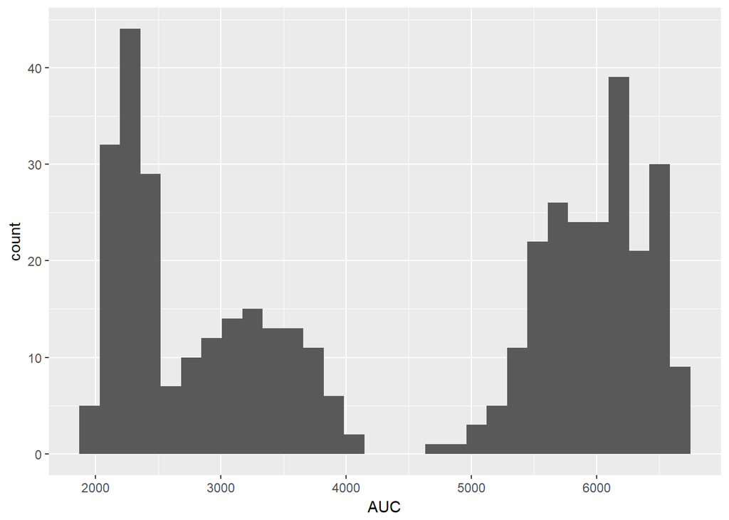

```r
#chack if AUC is normally distributed
ggplot(data=df2, aes(x=AUC))+geom_histogram() #-> it looks bimodal
```

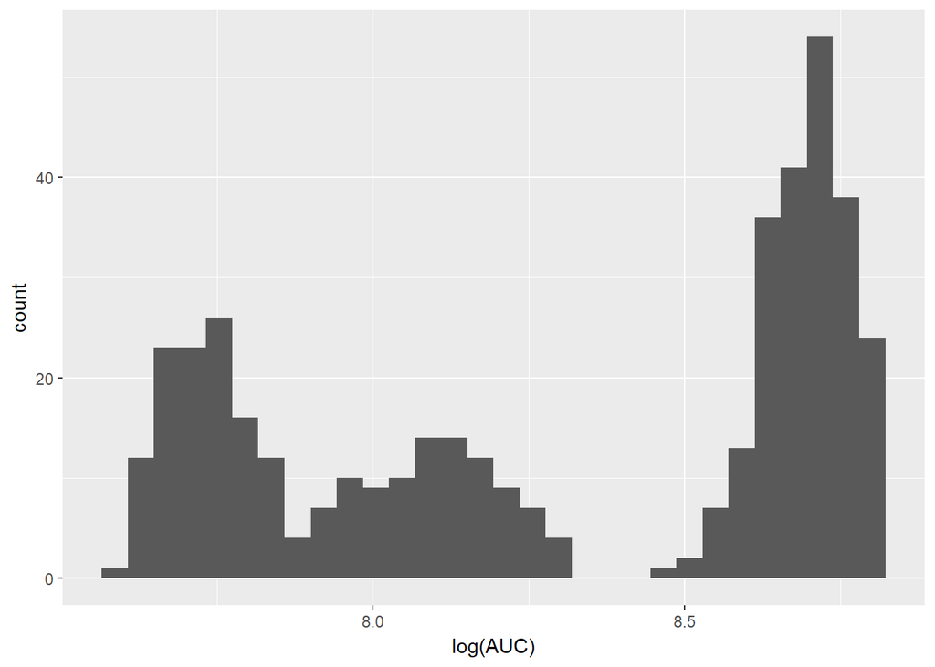

```r
ggplot(data = df2, aes(x=log(AUC)))+geom_histogram() #-> still very bimodal...
```

```r
#Since Gong et al., used log(AUC) for their analysis, I shall do the same
df2$logAUC=log(df2$AUC)

#Change subid to factor
is.numeric(df2$subid) #-> true
```

```
## [1] TRUE
```

```r
df2$subid=as.character(df2$subid); df2$subid=as.factor(df2$subid)
is.factor(df2$subid)#-> true
```

```
## [1] TRUE
```

```r
summary(df2$age_grp); summary(df2$donation); summary(df2$kinship)
```

```
##   old young
##   216   213
```

```
##    Length     Class      Mode
##       429 character character
```

```
##    Length     Class      Mode
##       429 character character
```

```r
# check that predictors are factors and AUC is numeric
is.factor(df2$age_grp); is.factor(df2$donation); is.factor(df2$kinship) #-> age_grp yes, others no
```

```
## [1] TRUE
```

```
## [1] FALSE
```

```
## [1] FALSE
```

```r
is.character(df2$donation)#-> true
```

```
## [1] TRUE
```

```r
df2$donation=as.factor(df2$donation); is.factor(df2$donation)
```

```
## [1] TRUE
```

```r
is.character(df2$kinship)#-> true
```

```
## [1] TRUE
```

```r
df2$kinship=as.factor(df2$kinship); is.factor(df2$kinship)
```

```
## [1] TRUE
```

```r
is.numeric(df2$logAUC)#-> True
```

```
## [1] TRUE
```

```r
# Run mixed ANOVA (without specifying that age_grp is observed)

#anova_AUC=ezANOVA(data = df2, wid=.(subid), dv=.(logAUC), within  = .(donation, kinship), between = .(age_grp), type = 3) #-> type=3 to emulate SPSS, indicate that age_grp is observed (rather than manipulated) to get more accurate eta_sq

#print(anova_AUC) #-> this run only when all the cells are full (i.e without removing outliers. I'm not sure what to do in case there will be ouliers, as there are ni this simulated data...)
```

```r
#One option- remove all observations of subjects with outliers
mon_counts=df2%>%filter(donation=="mon")%>%group_by(subid)%>%summarise(AUC_obs=length(AUC), k_obs=length(k))%>%ungroup()
min(mon_counts$AUC_obs); min(mon_counts$k_obs)#-> check for issues
```

```
## [1] 2
```

```
## [1] 2
```

```r
time_counts=df2%>%filter(donation=="time")%>%group_by(subid)%>%summarise(AUC_obs=length(AUC), k_obs=length(k))%>%ungroup()
min(time_counts$AUC_obs); min(time_counts$k_obs)#-> check for issues.
```

```
## [1] 1
```

```
## [1] 1
```

```r
#create a vector with subid's of problematic participants
p_remove_mon=c()
p_remove_time=c()
for (i in unique(df2$subid)){
  temp_mon=filter(mon_counts, subid==i)
  if(temp_mon$AUC_obs<2){
    p_remove_mon=c(p_remove_mon,print(i))}else{p_remove_mon=p_remove_mon}

  temp_time=filter(time_counts, subid==i)
  if(temp_time$AUC_obs<2){
    p_remove_time=c(p_remove_time,print(i))}else{p_remove_time=p_remove_time}
}
```

```
## [1] "65"
## [1] "73"
## [1] "94"
```

```r
#remove thse participants
df2_mon_crt=df2

for(i in p_remove_mon){df2_mon_crt=df2_mon_crt%>%filter(subid!=i)}

#create df with only correcr time donation values
df2_time_crt=df2

for(i in p_remove_time){df2_time_crt=df2_time_crt%>%filter(subid!=i)}
for(i in p_remove_mon){df2_time_crt=df2_time_crt%>%filter(subid!=i)}


#check that all were removed
#money
min(df2_mon_crt$AUC)<AUC_low; max(df2_mon_crt$AUC)>AUC_high
```

```
## [1] FALSE
```

```
## [1] FALSE
```

```r
#time
min(df2_time_crt$AUC)<AUC_low; max(df2_time_crt$AUC)>AUC_high
```

```
## [1] FALSE
```

```
## [1] FALSE
```

```r
anova_AUC2=ezANOVA(data = df2_time_crt, wid=.(subid), dv=.(logAUC), within  = .(donation, kinship), between = .(age_grp), type = 3, observed = .(age_grp)) #-> using  type=3 to emulate SPSS, indicate that age_grp is observed (rather than manipulated) to get more accurate eta_sq
print(anova_AUC2) #->this hacky thing works...But mentions that this might be a problem for type 3 sum of squares.
```

```
## $ANOVA
##                     Effect DFn DFd           F            p p<.05
## 2                  age_grp   1 103  287.681759 1.385733e-31     *
## 3                 donation   1 103 1212.405812 8.736996e-59     *
## 5                  kinship   1 103 3967.187231 4.633423e-84     *
## 4         age_grp:donation   1 103 1242.796001 2.692164e-59     *
## 6          age_grp:kinship   1 103 4528.194285 5.986663e-87     *
## 7         donation:kinship   1 103    3.494772 6.440341e-02
## 8 age_grp:donation:kinship   1 103    0.964181 3.284366e-01
##            ges
## 2 0.0572948856
## 3 0.1751498080
## 5 0.3651163584
## 4 0.2176639083
## 6 0.6564165296
## 7 0.0005086934
## 8 0.0001404161
```

```r
#The t-test of interest is comparing age_group AUC for time donation to relatives. Gong et al. found that older adults were more generous when donating time to relatives compared to young adults.
stats2=ezStats(data = df2_time_crt, wid=.(subid), dv=.(logAUC), within  = .(donation, kinship), between = .(age_grp), type = 3)
stats2
```

```
##   age_grp donation kinship  N     Mean         SD       FLSD
## 1     old      mon  nonrel 54 7.719387 0.06595558 0.03043006
## 2     old      mon     rel 54 8.723754 0.05678459 0.03043006
## 3     old     time  nonrel 54 7.729848 0.05999641 0.03043006
## 4     old     time     rel 54 8.720592 0.05547334 0.03043006
## 5   young      mon  nonrel 51 8.676055 0.07234099 0.03043006
## 6   young      mon     rel 51 8.664966 0.07239811 0.03043006
## 7   young     time  nonrel 51 8.108167 0.13942257 0.03043006
## 8   young     time     rel 51 8.053310 0.11446173 0.03043006
```

The main finding of interest, based on Gong et al’s results was that regradless of the age “main” effect, plder adults were more generous than young adults when donating time to relatives.

```r
#get the appropriate dataset
df2_tr_crt=df2_time_crt%>%filter(donation=="time", kinship=="rel")

#Post-hoc comparison of interest, using Bonferroni.
n_comparisons=2*2 #-> (there are 4 possible comparisons: old-young in both donations and both kinships)

#run t.test
t.1=t.test(data=df2_tr_crt, log(AUC)~age_grp) #-> run the test on the dataframe with only donation and time reported
print(t.1)
```

```
##
##  Welch Two Sample t-test
##
## data:  log(AUC) by age_grp
## t = 37.664, df = 71.332, p-value < 2.2e-16
## alternative hypothesis: true difference in means is not equal to 0
## 95 percent confidence interval:
##  0.6319591 0.7026053
## sample estimates:
##   mean in group old mean in group young
##            8.720592            8.053310
```

```r
t_interest=t.1$statistic; df_interest=t.1$parameter #-> get the value of the t-statistic and degrees of freedom
p_interest=t.1$p.value*n_comparisons #-> multiply by number of comparisons
```

# AUC plots

```r
#log AUC values, by age group for each donation*kinship condition
mean_and_ci <- df2_time_crt %>% #-> to get mean log(AUC) values and 95% C.Is in each condition
  group_by(age_grp, donation, kinship) %>%
  summarise(n = n(),
            mean = mean(log(AUC)),
            ci_lower = mean - qt(0.975, df = n-1) * sd(log(AUC))/sqrt(n),
            ci_upper = mean + qt(0.975, df = n-1) * sd(log(AUC))/sqrt(n))
mean_and_ci
```

```
## # A tibble: 8 x 7
## # Groups:   age_grp, donation [?]
##   age_grp donation kinship     n     mean ci_lower ci_upper
##    <fctr>   <fctr>  <fctr> <int>    <dbl>    <dbl>    <dbl>
## 1     old      mon  nonrel    54 7.719387 7.701384 7.737389
## 2     old      mon     rel    54 8.723754 8.708254 8.739253
## 3     old     time  nonrel    54 7.729848 7.713473 7.746224
## 4     old     time     rel    54 8.720592 8.705451 8.735734
## 5   young      mon  nonrel    51 8.676055 8.655709 8.696402
## 6   young      mon     rel    51 8.664966 8.644603 8.685328
## 7   young     time  nonrel    51 8.108167 8.068954 8.147381
## 8   young     time     rel    51 8.053310 8.021117 8.085503
```

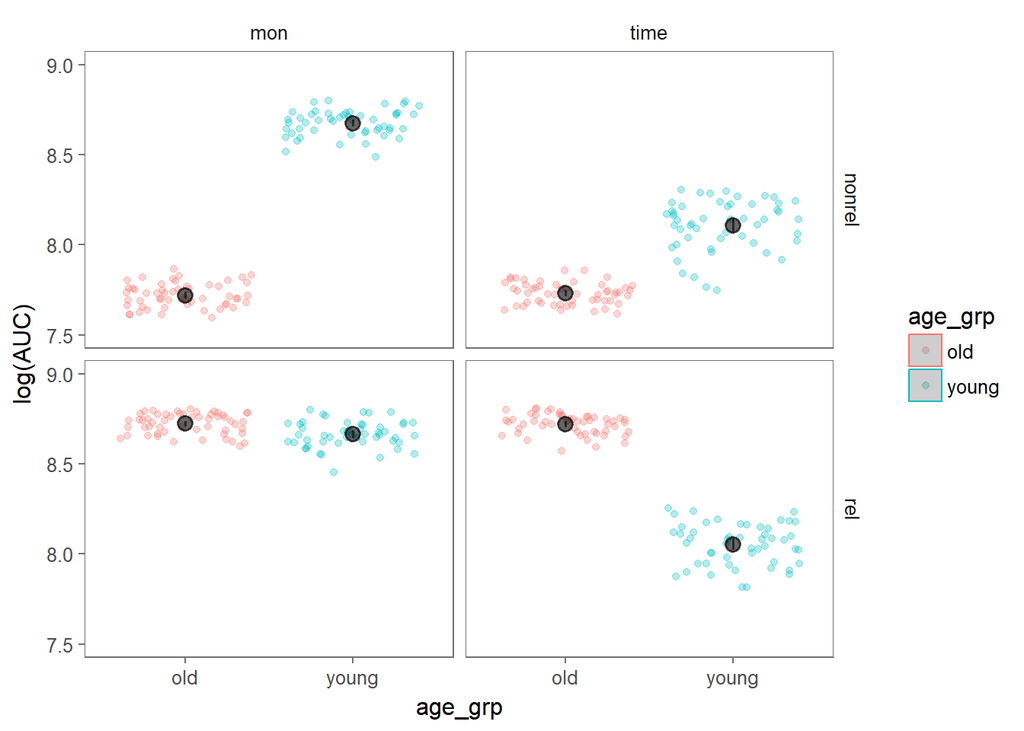

```r
mean_and_ci$age_grp=as.factor(mean_and_ci$age_grp)
mean_and_ci$donation=as.factor(mean_and_ci$donation)
mean_and_ci$kinship=as.factor(mean_and_ci$kinship)


#Plot
AUC_plots=ggplot(data = df2_time_crt, aes(x=age_grp, y=log(AUC),color=age_grp))+
  geom_point(position="jitter",alpha=0.3)+
  stat_summary(fun.y = "mean", geom="bar", alpha=0.3)+
  ylim(7.5,9)+
  geom_pointrange(data=mean_and_ci, aes(y=mean,ymin = ci_lower, ymax = ci_upper),color = "black",size=0.7, alpha=0.6)+
  facet_grid(kinship~donation)+
  ggthemes::theme_few()
ggsave("AUC_plots_simulated_data.png")
AUC_plots
```

## better analysis: mixed linear model with random subject intercepts and planned contrast

```r
#First set contrasts so that the intercept is the AUC value for older adults collapsing across donation and kinship conditions (to reflect the original "main" effect of age group)
## age group
contrasts(df2$age_grp)
```

```
##       young
## old       0
## young     1
```

```r
contrasts(df2$age_grp)=cbind('"Main"'=c(-1,1))#-> expecting older adults to be less generous overall, as was found in Gong et al.
## donation
contrasts(df2$donation)
```

```
##      time
## mon     0
## time    1
```

```r
contrasts(df2$donation)=cbind('"Main"'=c(1,-1)) #-> expecting participants to be more generous with money over time
## kinship
contrasts(df2$kinship)
```

```
##        rel
## nonrel   0
## rel      1
```

```r
contrasts(df2$kinship)=cbind('"Main"'=c(-1,1)) #-> expecting participants to be more generous to relatives over non-relatives

#Run lmer
lmer1=lmer(data=df2, log(AUC)~age_grp*donation*kinship+(1|subid), REML = F) #-> fitting with ML because we are interested in getting accurate estimates fir the parameters.

#Run lmer with covariates
lmer2=lmer(data=df2, log(AUC)~age_grp*donation*kinship+gender+incm_lv+edu_lv+num_friends+num_relatives+(1|subid), REML = F)

#Second-Set contrasts d=so that the interceot is the mean AUC for older adults, when donating time to relatives.
#In this case, the simple effect of age is the t-test of interest: the difference between older and younger adults when donating time to relatives.

## age group
contrasts(df2$age_grp)
```

```
##       "Main"
## old       -1
## young      1
```

```r
contrasts(df2$age_grp)=cbind('"Young"'=c(0,1))
## donation
contrasts(df2$donation)
```

```
##      "Main"
## mon       1
## time     -1
```

```r
contrasts(df2$donation)=cbind('"Money"'=c(1,0))
## kinship
contrasts(df2$kinship) #current intercept: old/mon/nonrel
```

```
##        "Main"
## nonrel     -1
## rel         1
```

```r
contrasts(df2$kinship)=cbind('"Non_relatives"'=c(1,0))

#Run lmer
lmer3=lmer(data=df2, log(AUC)~age_grp*donation*kinship+(1|subid), REML = F) #-> fitting with ML because we are interested in getting accurate estimates fir the parameters.

#Run lmer with covariates
lmer4=lmer(data=df2, log(AUC)~age_grp*donation*kinship+gender+incm_lv+edu_lv+num_friends+num_relatives+(1|subid), REML = F)

kable(tidy(lmer1))
```

| term | estimate | std.error | statistic | group |
| --- | --- | --- | --- | --- |
| (Intercept) | 8.2986161 | 0.0043953 | 1888.077327 | fixed |
| age_grp“Main” | 0.0752209 | 0.0043953 | 17.114038 | fixed |
| donation“Main” | 0.1469928 | 0.0038770 | 37.913602 | fixed |
| kinship“Main” | 0.2420140 | 0.0038771 | 62.421534 | fixed |
| age_grp“Main”:donation“Main” | 0.1488179 | 0.0038770 | 38.384347 | fixed |
| age_grp“Main”:kinship“Main” | -0.2567637 | 0.0038771 | -66.225863 | fixed |
| donation“Main”:kinship“Main” | 0.0075225 | 0.0038771 | 1.940233 | fixed |
| age_grp“Main”:donation“Main”:kinship“Main” | 0.0041167 | 0.0038771 | 1.061810 | fixed |
| sd_(Intercept).subid | 0.0215172 | NA | NA | subid |
| sd_Observation.Residual | 0.0802793 | NA | NA | Residual |

```r
kable(tidy(lmer3))
```

| term | estimate | std.error | statistic | group |
| --- | --- | --- | --- | --- |
| (Intercept) | 8.7205923 | 0.0113102 | 771.0356308 | fixed |
| age_grp“Young” | -0.6689549 | 0.0161463 | -41.4307449 | fixed |
| donation“Money” | 0.0031613 | 0.0154498 | 0.2046150 | fixed |
| kinship“Non_relatives” | -0.9907438 | 0.0154498 | -64.1268237 | fixed |
| age_grp“Young”:donation“Money” | 0.6117386 | 0.0219602 | 27.8566620 | fixed |
| age_grp“Young”:kinship“Non_relatives” | 1.0435217 | 0.0220147 | 47.4011152 | fixed |
| donation“Money”:kinship“Non_relatives” | -0.0136229 | 0.0218493 | -0.6234952 | fixed |
| age_grp“Young”:donation“Money”:kinship“Non_relatives” | -0.0329339 | 0.0310167 | -1.0618103 | fixed |
| sd_(Intercept).subid | 0.0215172 | NA | NA | subid |
| sd_Observation.Residual | 0.0802793 | NA | NA | Residual |

# k values, secondary analysis

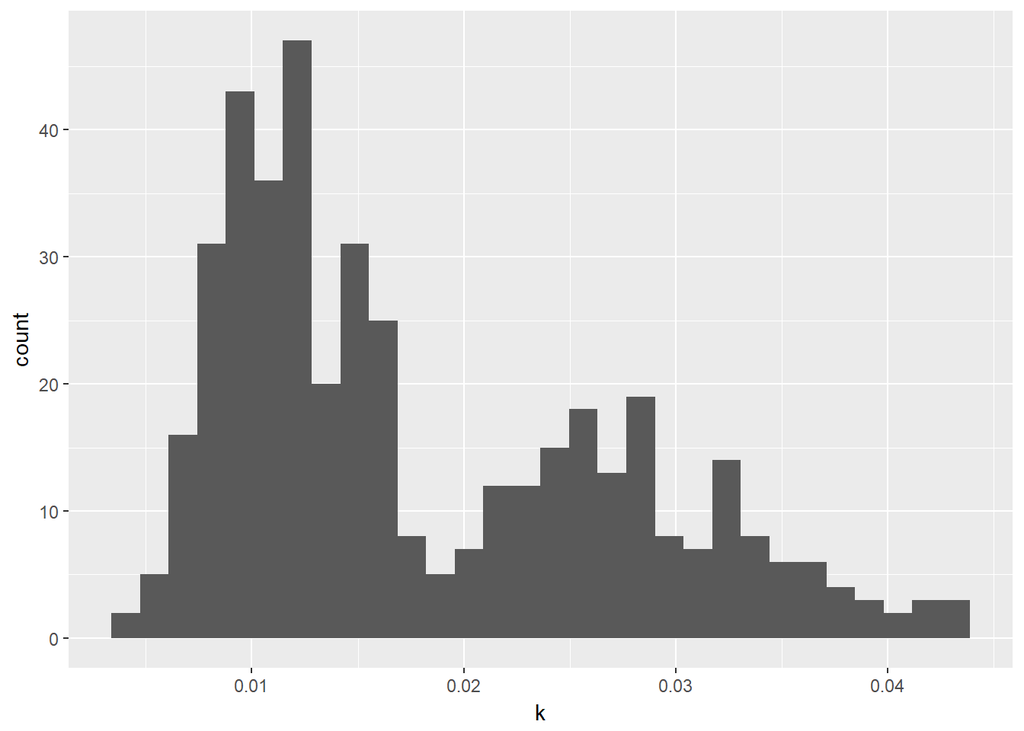

```r
#chack if AUC is normally distributed
ggplot(data=df2, aes(x=k))+geom_histogram() #-> positive skew
```

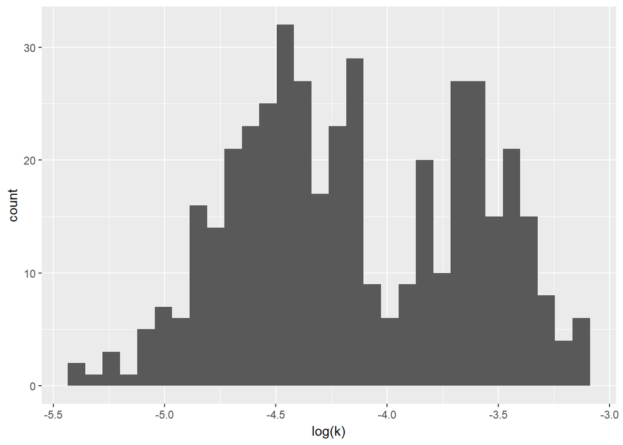

```r
ggplot(data = df2, aes(x=log(k)))+geom_histogram() #-> much better
```

```r
#Since Gong et al., used log(k) for their analysis, I shall do the same
df2$log_k=log(df2$k)


# check that k and log_k are numeric
is.numeric(df2$k);is.numeric(df2$log_k)#-> True, True
```

```
## [1] TRUE
```

```
## [1] TRUE
```

```r
# Run mixed ANOVA (without specifying that age_grp is observed)
#anova_k=ezANOVA(data = df2, wid=.(subid), dv=.(log_k), within  = .(donation, kinship), between = .(age_grp), type = 3) #-> type=3 to emulate SPSS, indicate that age_grp is observed (rather than manipulated) to get more accurate eta_sq

#print(anova_k) #-> this run only when all the cells are full (i.e without removing outliers. I'm not sure what to do in case there will be ouliers, as there are ni this simulated data...)
```

```r
min(mon_counts$k_obs) #-> no problem with money donations
```

```
## [1] 2
```

```r
min(time_counts$k_obs) #-> some participants have problematic (+/- 3s.d) time discount rates
```

```
## [1] 1
```

```r
#create a vector with subid's of problematic participants
p_remove_mon=c()
p_remove_time=c()
for (i in unique(df2$subid)){
  temp_mon=filter(mon_counts, subid==i)
  if(temp_mon$k_obs<2){
    p_remove_mon=c(p_remove_mon,print(i))}else{p_remove_mon=p_remove_mon}

  temp_time=filter(time_counts, subid==i)
  if(temp_time$k_obs<2){
    p_remove_time=c(p_remove_time,print(i))}else{p_remove_time=p_remove_time}
}
```

```
## [1] "65"
## [1] "73"
## [1] "94"
```

```r
#remove thse participants
df2_mon_crt=df2

for(i in p_remove_mon){df2_mon_crt=df2_mon_crt%>%filter(subid!=i)}

#create df with only correcr time donation values
df2_time_crt=df2

for(i in p_remove_time){df2_time_crt=df2_time_crt%>%filter(subid!=i)}
```

```r
anova_k=ezANOVA(data = df2_time_crt, wid=.(subid), dv=.(log_k), within  = .(donation, kinship), between = .(age_grp),observed = .(age_grp), type = 3) #-> type=3 to emulate SPSS, indicate that age_grp is observed (rather than manipulated) to get more accurate eta_sq
print(anova_k) #-> comment main results (Gong et al. found sig. age_grp*donation interaction (as well as kinship*donation which is not of interest)
```

```
## $ANOVA
##                     Effect DFn DFd            F            p p<.05
## 2                  age_grp   1 103  27.46089134 8.558230e-07     *
## 3                 donation   1 103   0.23895706 6.259996e-01
## 5                  kinship   1 103 884.66575029 2.273028e-52     *
## 4         age_grp:donation   1 103  84.40201753 4.742520e-15     *
## 6          age_grp:kinship   1 103 466.39666899 4.944665e-40     *
## 7         donation:kinship   1 103   0.02885148 8.654556e-01
## 8 age_grp:donation:kinship   1 103   0.34830907 5.563645e-01
##            ges
## 2 3.844153e-02
## 3 2.697641e-04
## 5 4.373769e-01
## 4 9.530908e-02
## 6 4.098402e-01
## 7 2.942414e-05
## 8 3.552329e-04
```

```r
#Gong et al found that there was no difference in discounting for time donations regardless of kinship, but that older adults discounted money donation more so than yound adults, in both donation conditions

#get the appropriate datasets-
df2_mr_crt=df2_time_crt%>%filter(donation=="mon", kinship=="rel")
df2_mnr_crt=df2_time_crt%>%filter(donation=="mon", kinship=="nonrel")
df2_tr_crt=df2_time_crt%>%filter(donation=="time", kinship=="rel")
df2_tnr_crt=df2_time_crt%>%filter(donation=="time", kinship=="nonrel")

#Post-hoc comparison of interest, using Bonferroni.
n_comparisons=2*2 #-> (there are 4 possible comparisons: old-young in both donations and both kinships)

##run t.tests
#money, relatives
t.2a=t.test(df2_mr_crt$log_k~df2_mr_crt$age_grp)
print(t.2a)
```

```
##
##  Welch Two Sample t-test
##
## data:  df2_mr_crt$log_k by df2_mr_crt$age_grp
## t = -1.6993, df = 94.795, p-value = 0.09254
## alternative hypothesis: true difference in means is not equal to 0
## 95 percent confidence interval:
##  -0.21909058  0.01700415
## sample estimates:
##   mean in group old mean in group young
##           -4.584222           -4.483179
```

```r
pt.2a=t.2a$p.value*n_comparisons

#money, nonrelatives
t.2b=t.test(df2_mnr_crt$log_k~df2_mnr_crt$age_grp)
print(t.2b)
```

```
##
##  Welch Two Sample t-test
##
## data:  df2_mnr_crt$log_k by df2_mnr_crt$age_grp
## t = 18.907, df = 79.289, p-value < 2.2e-16
## alternative hypothesis: true difference in means is not equal to 0
## 95 percent confidence interval:
##  0.8735007 1.0790402
## sample estimates:
##   mean in group old mean in group young
##           -3.525353           -4.501624
```

```r
pt.2b=t.2b$p.value*n_comparisons

#time, relatives
t.2c=t.test(df2_tr_crt$log_k~df2_tr_crt$age_grp)
print(t.2c)
```

```
##
##  Welch Two Sample t-test
##
## data:  df2_tr_crt$log_k by df2_tr_crt$age_grp
## t = -10.457, df = 91.087, p-value < 2.2e-16
## alternative hypothesis: true difference in means is not equal to 0
## 95 percent confidence interval:
##  -0.7960811 -0.5419209
## sample estimates:
##   mean in group old mean in group young
##           -4.610627           -3.941626
```

```r
pt.2c=t.2c$p.value*n_comparisons

#time, nonrelatives
t.2d=t.test(df2_tnr_crt$log_k~df2_tnr_crt$age_grp)
print(t.2d)
```

```
##
##  Welch Two Sample t-test
##
## data:  df2_tnr_crt$log_k by df2_tnr_crt$age_grp
## t = 8.2023, df = 69.19, p-value = 8.373e-12
## alternative hypothesis: true difference in means is not equal to 0
## 95 percent confidence interval:
##  0.3584708 0.5888708
## sample estimates:
##   mean in group old mean in group young
##           -3.538648           -4.012319
```

```r
pt.2d=t.2d$p.value*n_comparisons
```

# k plots

```r
#log k values, by age group for each donation*kinship condition
mean_and_ci <- df2_time_crt %>% #-> to get mean log(AUC) values and 95% C.Is in each condition
  group_by(age_grp, donation, kinship) %>%
  summarise(n = n(),
            mean = mean(log(k)),
            ci_lower = mean - qt(0.975, df = n-1) * sd(log(AUC))/sqrt(n),
            ci_upper = mean + qt(0.975, df = n-1) * sd(log(AUC))/sqrt(n))
mean_and_ci
```

```
## # A tibble: 8 x 7
## # Groups:   age_grp, donation [?]
##   age_grp donation kinship     n      mean  ci_lower  ci_upper
##    <fctr>   <fctr>  <fctr> <int>     <dbl>     <dbl>     <dbl>
## 1     old      mon  nonrel    54 -3.525353 -3.543356 -3.507351
## 2     old      mon     rel    54 -4.584222 -4.599722 -4.568723
## 3     old     time  nonrel    54 -3.538648 -3.555024 -3.522272
## 4     old     time     rel    54 -4.610627 -4.625768 -4.595486
## 5   young      mon  nonrel    51 -4.501624 -4.521970 -4.481277
## 6   young      mon     rel    51 -4.483179 -4.503541 -4.462817
## 7   young     time  nonrel    51 -4.012319 -4.051532 -3.973106
## 8   young     time     rel    51 -3.941626 -3.973819 -3.909433
```

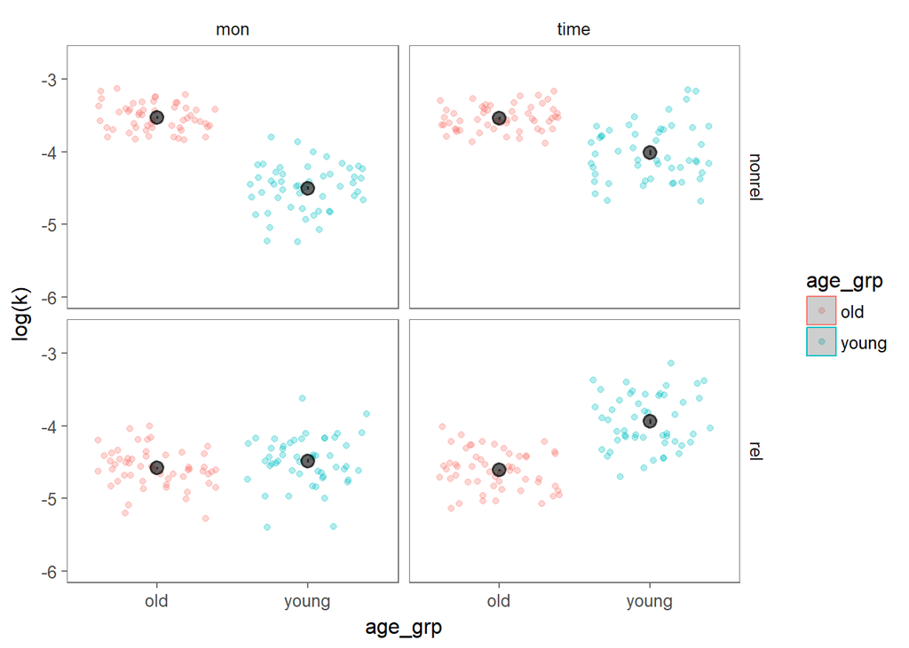

```r
mean_and_ci$age_grp=as.factor(mean_and_ci$age_grp)
mean_and_ci$donation=as.factor(mean_and_ci$donation)
mean_and_ci$kinship=as.factor(mean_and_ci$kinship)


#Plot
k_plots=ggplot(data = df2_time_crt, aes(x=age_grp, y=log(k),color=age_grp))+
  geom_point(position="jitter",alpha=0.3)+
  stat_summary(fun.y = "mean", geom="bar", alpha=0.3)+
  ylim(-6,-2.7)+
  geom_pointrange(data=mean_and_ci, aes(y=mean,ymin = ci_lower, ymax = ci_upper),color = "black",size=0.7, alpha=0.6)+
  facet_grid(kinship~donation)+
  ggthemes::theme_few()
k_plots
```